# Score

Uwe Sterr

3/22/2020

## Corona data in Germany

Der Corona Hub von Esri stellt relevante, kartographische Informationsebenen bereit. Diese werden im Zusammenhang mit dem Monitoring der Corona Virus Ausbreitung genutzt. Zusätzlich zu den raumbezogenen Fallzahlen ergeben sich dadurch weitere Informationen, die durch Gesellschaft, Politik, Verwaltung, Wissenschaft und Wirtschaft genutzt werden können.

### RKI Corona Bundesländer

Feature Service mit den aktuellen Covid-19 Infektionen pro 100.000 Einwohner auf die deutschen Bundesländer. Der Service wird täglich mit den aktuellen Fallzahlen des Robert Koch-Instituts aktualisiert. More details at https://npgeo-corona-npgeo-de.hub.arcgis.com/datasets/ef4b445a53c1406892257fe63129a8ea_0?geometry=-23.183%2C46.270%2C39.439%2C55.886&selectedAttribute=faelle_100000_EW

JSON API at: https://services7.arcgis.com/mOBPykOjAyBO2ZKk/arcgis/rest/services/Coronaf%C3%A4lle_in_den_Bundesl%C3%A4ndern/FeatureServer/0/query?where=1%3D1&outFields=*&outSR=4326&f=json

### RKI Corona Landkreise

Feature Service mit den aktuellen Covid-19 Infektionen pro 1 00.000 Einwohner auf die deutschen Landkreise. Der Service wird täglich mit den aktuellen Fallzahlen des Robert Koch-Instituts aktualisiert. More details at https://npgeo-corona-npgeo-de.hub.arcgis.com/datasets/917fc37a709542548cc3be077a786c17_0?geometry=-20.857%2C46.269%2C41.765%2C55.886

JSON API at: https://services7.arcgis.com/mOBPykOjAyBO2ZKk/arcgis/rest/services/RKI_Landkreisdaten/FeatureServer/0/query?where=1%3D1&outFields=*&outSR=4326&f=json

### RKI historical data

Tabelle mit den aktuellen Covid-19 Infektionen pro Tag. Die Tabelle wird täglich mit den aktuellen Fallzahlen des Robert Koch-Instituts aktualisiert.

JSON API at: https://services7.arcgis.com/mOBPykOjAyBO2ZKk/arcgis/rest/services/RKI_COVID19/FeatureServer/0/query?where=1%3D1&outFields=*&outSR=4326&f=json (Meldedatum is in JSON time stamp format, i.e. Unix time in ms)

use instead https://opendata.arcgis.com/datasets/dd4580c810204019a7b8eb3e0b329dd6_0.geojson

An excel sheet is avaialble at ‘https://opendata.arcgis.com/datasets/dd4580c810204019a7b8eb3e0b329dd6_0.csv’

It offers the following attributes

- Altergruppe (Text)
- AnzahlFall (Number)
- AnzahlTodesfall (Number)
- Bundesland (Text)
- Datenstand (Text)
- Geschlecht (Text)
- IdBundesland (Number)
- Landkreis (Text)
- LandkreisId (Text)
- Meldedatum (Date or Time)
- ObjectId (UNique ID)

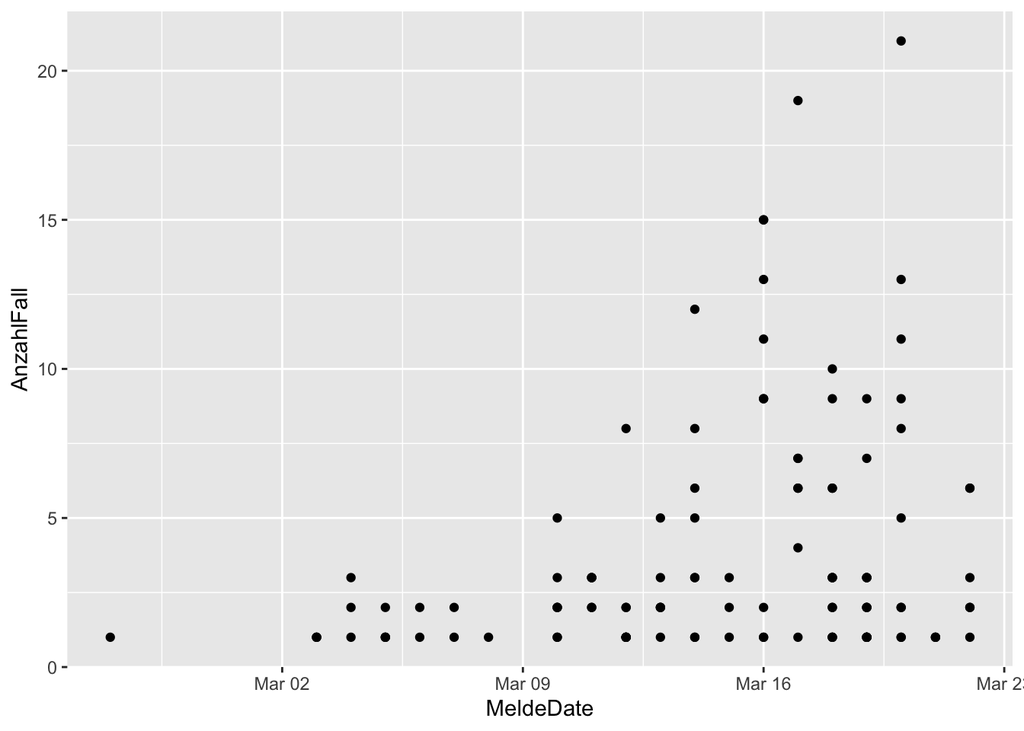

## Thomas Excel sheet

### parameters

- Gesamt zu erwartende Infizierte: 5.8110^{7}
- Gesamtanzahl erfasster Infizierter: 3.873333310^{6}
- Reproduktionsrate pro Tag: 1.2923922

```
Tägiche Reproduktionsrate Rt=IF(B2<=0,0,MAX(Rt-F2*(Rt-1)/Y_inf_limit,0))
Aktuell Infizierte berechnet=D3+SUM(INDIRECT("e"&ROW()-1&":e"&MAX(ROW()-(ta-1),2)))
Restanteil Startwert=IF(ROW()<ta+2,n0_erfasst*(ta-ROW()+2)/ta,0)
Neu Infizierte berechnet=H3/faktor_n_inf
Erfasste Infizierte berechnet=MIN(E2+F2,Y_inf_limit)
Gesamt Infizierte berechnet=MIN(H2+G2,Ygesamt*ges_inf_rate)
Neu gesamt Infizierte berechnet=(B3-1)*G3
HZ1=IF(ROW()>dt_inf_kh+1,"E"&ROW()-dt_inf_kh,0)
HZ2=IF(ROW()>dt_inf_kh+1,    "E"&(ROW()-MIN(t_kh+dt_inf_kh,ROW()-2)),0)
KH berechnet=IF(ROW()>dt_inf_kh+1,kh_normal*SUM(INDIRECT(I3):INDIRECT(J3)),0.1)
HZ3=IF(ROW()>dt_inf_kh+dt_kh_int+1,"E"&ROW()-dt_inf_kh-dt_kh_int,0)
HZ4=IF(ROW()>dt_kh_int+dt_inf_kh+1,    "E"&(ROW()-MIN(t_intensiv+dt_kh_int+dt_inf_kh-1,ROW()-2-dt_inf_kh+dt_inf_kh)),0)
Intensiv berechnet=IF(ROW()>dt_kh_int+dt_inf_kh+1,kh_normal*kh_intensiv*SUM(INDIRECT(L3):INDIRECT(M3)),0.1)
HZ5=IF(ROW()>td_tod+1,"E"&(ROW()-td_tod),0)
Neue Tote berechnet=IF(ROW()>td_tod+1,  tod_rate*@INDIRECT(O3),0.1)
Tote berechnet=P2+Q2
```

Kumulierte Infizierte /Tote

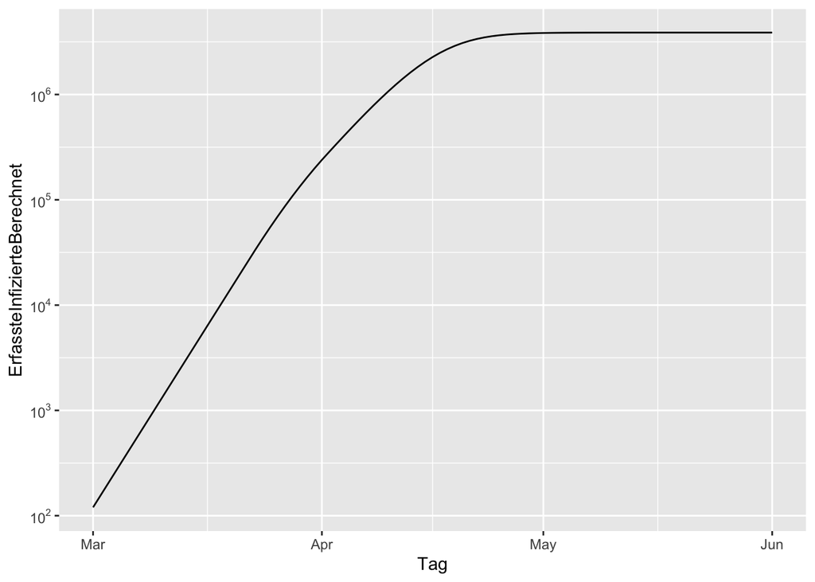

Verlauf Infizierte

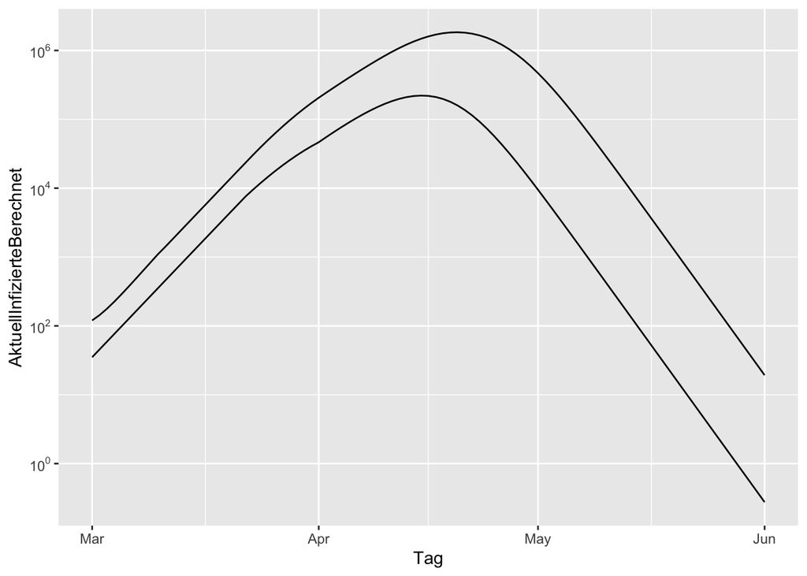

Plätze im Krankenhaus

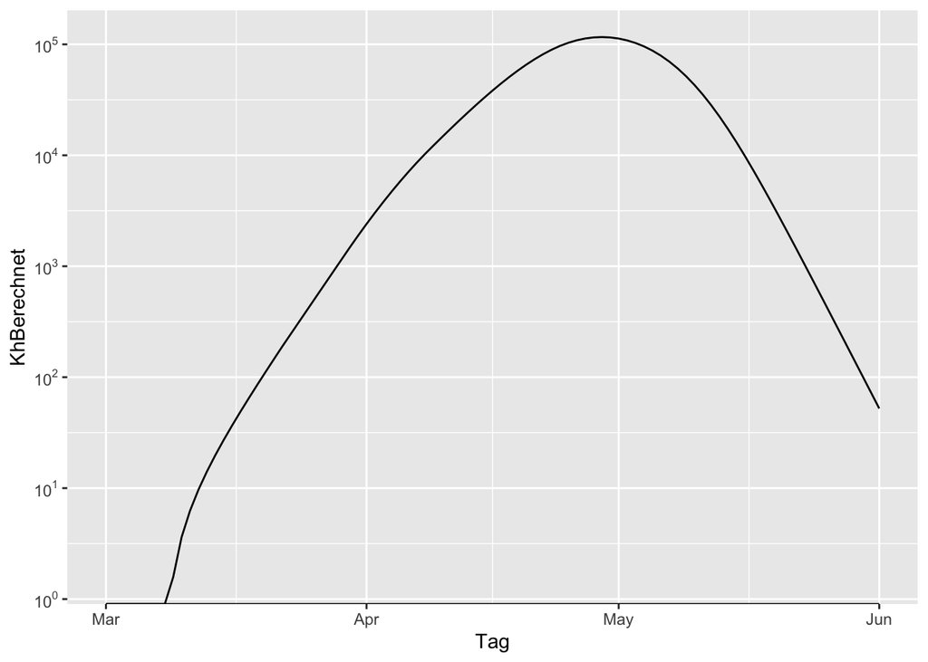

Reproduktionsrate

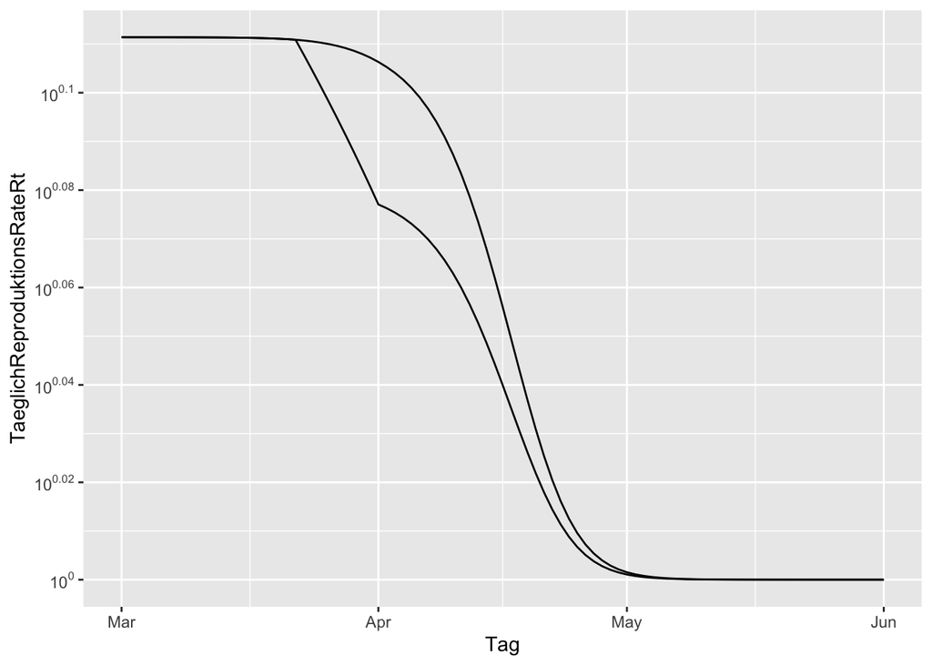

# R package covid19germany

https://github.com/nevrome/covid19germany

```
## # A tibble: 12,773 x 13
##    IdBundesland Bundesland Landkreis Altersgruppe Geschlecht AnzahlFall
##           <int> <chr>      <chr>     <ord>        <fct>           <int>
##  1            3 Niedersac… LK Cuxha… A35-A59      M                   2
##  2            3 Niedersac… LK Cuxha… A35-A59      M                   1
##  3            3 Niedersac… LK Cuxha… A35-A59      W                   1
##  4            3 Niedersac… LK Cuxha… A35-A59      W                   2
##  5            3 Niedersac… LK Cuxha… A35-A59      W                   3
##  6            3 Niedersac… LK Cuxha… A35-A59      W                   3
##  7            3 Niedersac… LK Cuxha… A60-A79      M                   1
##  8            3 Niedersac… LK Cuxha… A60-A79      M                   1
##  9            3 Niedersac… LK Cuxha… A60-A79      M                   1
## 10            3 Niedersac… LK Cuxha… A60-A79      M                   1
## # … with 12,763 more rows, and 7 more variables: AnzahlTodesfall <int>,
## #   ObjectId <int>, Meldedatum <dttm>, IdLandkreis <int>, Datenstand <chr>,
## #   NeuerFall <dbl>, NeuerTodesfall <dbl>
```

```
## # A tibble: 16 x 6
##    Bundesland             FlaecheKm2 EwGesamt EwMaennlich EwWeiblich EwProKm2
##    <chr>                       <dbl>    <int>       <int>      <int>    <dbl>
##  1 Schleswig-Holstein         15804.  2896712     1419457    1477255      183
##  2 Hamburg                      755.  1841179      902048     939131     2438
##  3 Niedersachsen              47710.  7982448     3943243    4039205      167
##  4 Bremen                       419.   682986      338035     344951     1629
##  5 Nordrhein-Westfalen        34112. 17932651     8798631    9134020      526
##  6 Hessen                     21116.  6265809     3093044    3172765      297
##  7 Rheinland-Pfalz            19852.  4084844     2017576    2067268      206
##  8 Baden-Württemberg          35748. 11069533     5501693    5567840      310
##  9 Bayern                     70542. 13076721     6483793    6592928      185
## 10 Saarland                    2571.   990509      486159     504350      385
## 11 Berlin                       891.  3644826     1792801    1852025     4090
## 12 Brandenburg                29654.  2511917     1239460    1272457       85
## 13 Mecklenburg-Vorpommern     23294.  1609675      793639     816036       69
## 14 Sachsen                    18450.  4077937     2009619    2068318      221
## 15 Sachsen-Anhalt             20454.  2208321     1086679    1121642      108
## 16 Thüringen                  16202.  2143145     1060814    1082331      132
```

```
## # A tibble: 401 x 8
##    IdLandkreis NameLandkreis NUTS3 FlaecheKm2 EwGesamt EwMaennlich EwWeiblich
##          <int> <chr>         <chr>      <dbl>    <int>       <int>      <int>
##  1        1001 Flensburg, S… DEF01       56.7    89504       44599      44905
##  2        1002 Kiel, Landes… DEF02      119.    247548      120566     126982
##  3        1003 Lübeck, Hans… DEF03      214.    217198      104371     112827
##  4        1004 Neumünster, … DEF04       71.7    79487       39241      40246
##  5        1051 Dithmarschen  DEF05     1428.    133210       65720      67490
##  6        1053 Herzogtum La… DEF06     1263.    197264       96881     100383
##  7        1054 Nordfriesland DEF07     2084.    165507       81099      84408
##  8        1055 Ostholstein   DEF08     1393.    200581       96765     103816
##  9        1056 Pinneberg     DEF09      664.    314391      154211     160180
## 10        1057 Plön          DEF0A     1084.    128647       62532      66115
## # … with 391 more rows, and 1 more variable: EwProKm2 <dbl>
```

```
## # A tibble: 16 x 7
##    Bundesland AnzahlKrankenha… AnzahlKrankenha… AnzahlBettenInt…
##    <chr>      <chr>                       <int>            <int>
##  1 Baden-Wür… 265                           123             3262
##  2 Bayern     354                           178             3790
##  3 Berlin     83                             35             1450
##  4 Brandenbu… 57                             46              745
##  5 Bremen     14                             10              294
##  6 Hamburg    58                             25              802
##  7 Hessen     159                            91             1845
##  8 Mecklenbu… 39                             30             1014
##  9 Niedersac… 180                           116             2362
## 10 Nordrhein… 344                           263             6148
## 11 Rheinland… 87                             58             1343
## 12 Saarland   23                             18              548
## 13 Sachsen    77                             69             1859
## 14 Sachsen-A… 48                             34              972
## 15 Schleswig… 111                            34              867
## 16 Thüringen  43                             30              730
## # … with 3 more variables: AnzahlBelegungstageIntensiv <int>,
## #   AnzahlBehandlungsfaelleIntensiv <int>,
## #   AnzahlBehandlungsfaelleIntensivmitBeatmung <int>
```

Simple plots

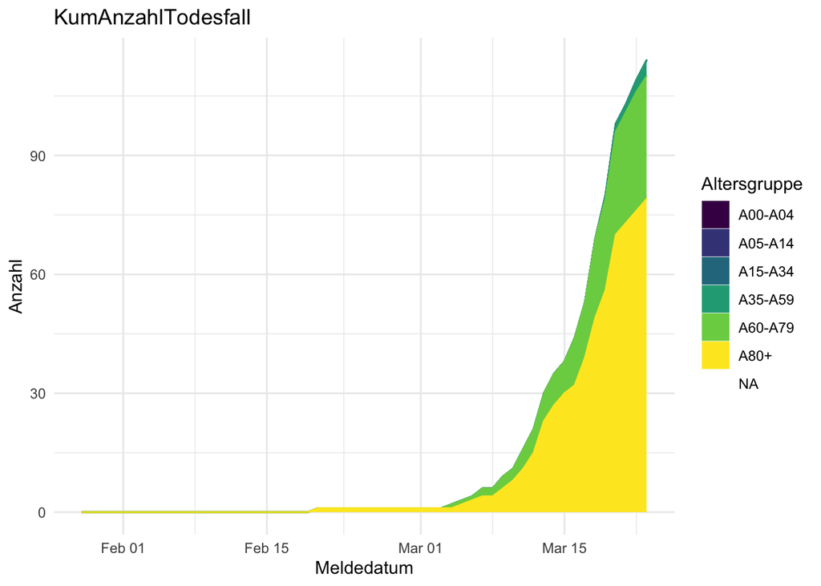

Daily reported cases by federal state

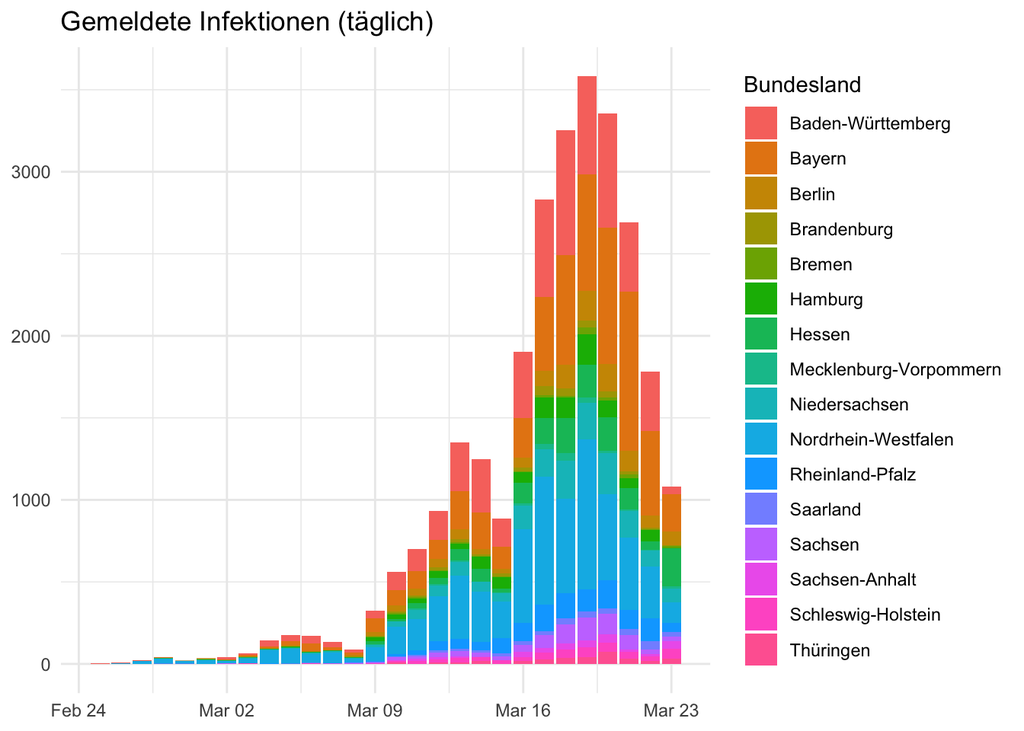

Cumulative cases by federal state

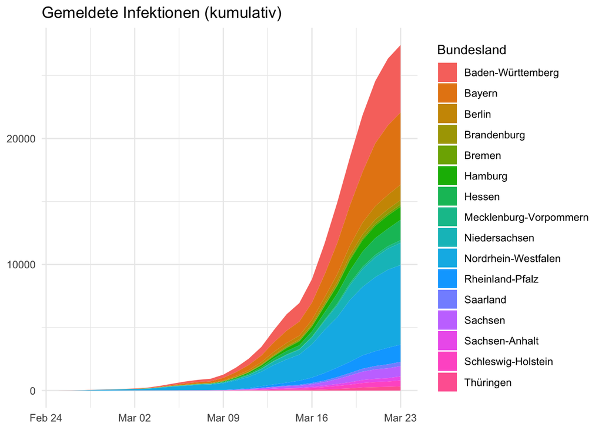

Cumulative per inhabitants

[figure not shown]